# Understanding Stock Price Beahavior using an R Based Analytical Framework

Francis Kurian

10/8/2021

Stock market behavior is a well researched area with plenty of historic information available free. Several studies link the stock price movement of a company to the perception of the market participant about that company.IBM Watson APIs enable tracking of company specific news and social media interactions through extensive text mining and help come out with a Sentiment (Negative and positive emotions expressed through words or text) Index for a business.Business Sentiment Index(BSI) is one such index calculated by TRaiCE Fintech at company level. In addition, to understand sensitivity of stock prices to Global events, Foreign Exchanges Rate is also introduced as an additional measure. Idea here is to demonstrate how to extract various relevant data elements from diverse sources, transform and load them into an analytic framework to visualize and understand the inherent relationships.

Primary objective is to develop an analysis system using various R libraries. Extracting and processing data from multiple sources, data cleaning, simplifying repetitive tasks using control structures and functions, use of data visualization techniques and application of statistical methods are the focus areas while building the framework in R. In other words, learn to write reproducible R code while analyzing stock price movement with respect to Business Sentiment Index(BSI) and Foreign Exchange Rate is the objective of this project.

For this project the following Libraries are used for data validation, graphics and statistical analysis

```r
library(ggplot2)
library(tidyr)
library(plyr)
library(lubridate)
library(scales)
library(reshape2)
library(summarytools) #dataframe summaries
library(ggfortify) #autoplot
library(sjPlot) #tabmodel
```

### 1.List of companies to Analyze: Internally created CSV

### 2.Foreign Exchange daily data for various currencies: https://www.federalreserve.gov

### 3.Daily Stock Prices: https://finance.yahoo.com

### 4.Business Sentiments Index(BSI,IBM Watson API based): https://www.traice.io

```r
CompanyNames <- './data/CompanyNames.csv'
df_companies <- read.csv(CompanyNames, header = T)
head(df_companies) #list records
```

|  | ticker | name |
| --- | --- | --- |
| 1 | GE | General Electric Company |
| 2 | BA | The Boeing Company |
| 3 | F | Ford Motor Company |
| 4 | FE | First Energy Corp |
| 5 | KHC | The Kraft Heinz Company |
| 6 | OXY | Occidental Petroleum Corporation |

```r
ForexFile <- './data/FederalReserve_CurrencyXchangeRate.csv'
headers <- read.csv(ForexFile, skip = 5 , header = F, nrows = 1)#header info at row #6
df_forex <- read.csv(ForexFile, skip = 6, header = F) #data begins at row #7
colnames(df_forex) <- headers #apply headers
df_forex$period <- as.Date(df_forex$`Time Period`) #format as date

df_forex$USDxINR <- as.numeric(gsub("ND","",df_forex$RXI_N.B.IN))#clean & format as number
df_forex$USDxEUR <- as.numeric(gsub("ND","",df_forex$`RXI$US_N.B.EU`))
df_forex$USDxYEN <- as.numeric(gsub("ND","",df_forex$RXI_N.B.JA))

df_forex <- subset(df_forex,select = c(period, USDxINR, USDxEUR, USDxYEN))
df_forex <- df_forex[!duplicated(df_forex$period),] # remove duplicates
df_forex2 <- melt(df_forex, id.vars="period") # for all in one graphs

sapply(df_forex, class) #check data structure
```

```
##    period   USDxINR   USDxEUR   USDxYEN
##    "Date" "numeric" "numeric" "numeric"
```

```r
head(df_forex)
```

|  | period | USDxINR | USDxEUR | USDxYEN |
| --- | --- | --- | --- | --- |
| 1 | 2019-01-01 | NA | NA | NA |
| 2 | 2019-01-02 | 70.02 | 1.1357 | 109.22 |
| 3 | 2019-01-03 | 70.12 | 1.1399 | 108.07 |
| 4 | 2019-01-04 | 69.63 | 1.1410 | 108.29 |
| 5 | 2019-01-07 | 69.78 | 1.1468 | 108.62 |
| 6 | 2019-01-08 | 70.11 | 1.1444 | 108.57 |

```r
summary(df_forex) #check distribution, missing values
```

```
##      period              USDxINR         USDxEUR         USDxYEN
##  Min.   :2019-01-01   Min.   :68.40   Min.   :1.068   Min.   :102.5
##  1st Qu.:2019-09-05   1st Qu.:71.04   1st Qu.:1.112   1st Qu.:106.5
##  Median :2020-05-11   Median :72.97   Median :1.134   Median :108.5
##  Mean   :2020-05-10   Mean   :72.62   Mean   :1.148   Mean   :108.1
##  3rd Qu.:2021-01-13   3rd Qu.:74.26   3rd Qu.:1.184   3rd Qu.:109.7
##  Max.   :2021-09-17   Max.   :76.95   Max.   :1.230   Max.   :112.0
##                       NA's   :31      NA's   :31      NA's   :31
```

```r
for (i in df_companies$ticker) {

  if (!file.exists(paste0("./data/",i, ".csv"))) {
    print("Please remove the Company. Files Missing for:")
    print(i)
    break
  }

  #process stock price/volume files from data directory
  #pick the csv file of every company in the input list and create a dataframe in a loop

  df_c <- read.csv(paste0("./data/",i, ".csv"), header = T)
  df_c$period <- as.Date(df_c$Date) # add a date field
  df_c$ticker <- i # attach ticker
  df_companies_subset <- subset(df_companies, ticker==i)
  df_c <- merge(x=df_c, y=df_companies_subset, by="ticker",all.x=TRUE )#to get name
  assign(paste0("df_",i), df_c) #create a new data frame for later use

  # Appends company data frames to one for graphs.

  if (exists("df_c_all")) {
    df_c_all <- rbind(df_c_all, df_c)

  }else {
    df_c_all=df_c}

  # Process Sentiments Index from data directory

  df_bsi <- read.csv(paste0("./data/",i, "_BSI.csv"), header = T)
  df_bsi$period <- as.Date(parse_date_time(df_bsi$created_date, c('%Y-%m-%d', '%m/%d/%y')))
  df_bsi$ticker <- i # attach ticker
  df_bsi <- merge(x=df_bsi, y=df_companies_subset, by="ticker",all.x=TRUE )##to get name
  df_bsi <- df_bsi[c('ticker','period','name','bsi_score')]

  assign(paste0("df_",i,"_BSI"), df_bsi) #create a new data frame forlater use

  # create a data frame to append  every data frame for graphs

  if (exists("df_bsi_all")) {
    df_bsi_all <- rbind(df_bsi_all, df_bsi)

  }else {
    df_bsi_all <- df_bsi}

}
```

```
## [1] "Please remove the Company. Files Missing for:"
## [1] "TEST"
```

```r
summary(df_c_all) # Stock price series
```

```
##     ticker              Date                Open             High
##  Length:4165        Length:4165        Min.   :  4.27   Min.   :  4.42
##  Class :character   Class :character   1st Qu.: 26.26   1st Qu.: 26.81
##  Mode  :character   Mode  :character   Median : 39.74   Median : 40.36
##                                        Mean   : 77.14   Mean   : 78.23
##                                        3rd Qu.: 81.20   3rd Qu.: 82.80
##                                        Max.   :446.01   Max.   :446.01
##       Low             Close          Adj.Close          Volume
##  Min.   :  3.96   Min.   :  4.01   Min.   :  4.01   Min.   :   958300
##  1st Qu.: 25.73   1st Qu.: 26.26   1st Qu.: 25.28   1st Qu.:  5154700
##  Median : 39.27   Median : 39.85   Median : 37.90   Median :  9205138
##  Mean   : 75.97   Mean   : 77.07   Mean   : 75.60   Mean   : 19959508
##  3rd Qu.: 80.16   3rd Qu.: 81.28   3rd Qu.: 80.53   3rd Qu.: 23073575
##  Max.   :440.19   Max.   :440.62   Max.   :430.30   Max.   :282394100
##      period               name
##  Min.   :2018-12-31   Length:4165
##  1st Qu.:2019-09-10   Class :character
##  Median :2020-05-18   Mode  :character
##  Mean   :2020-05-17
##  3rd Qu.:2021-01-26
##  Max.   :2021-10-01
```

```r
summary(df_bsi_all) #BSI index series
```

```
##     ticker              period               name             bsi_score
##  Length:3012        Min.   :2019-08-27   Length:3012        Min.   :-19.00
##  Class :character   1st Qu.:2020-02-28   Class :character   1st Qu.:  6.00
##  Mode  :character   Median :2020-08-26   Mode  :character   Median : 15.00
##                     Mean   :2020-08-27                      Mean   : 13.26
##                     3rd Qu.:2021-03-01                      3rd Qu.: 27.00
##                     Max.   :2021-08-27                      Max.   : 62.00
```

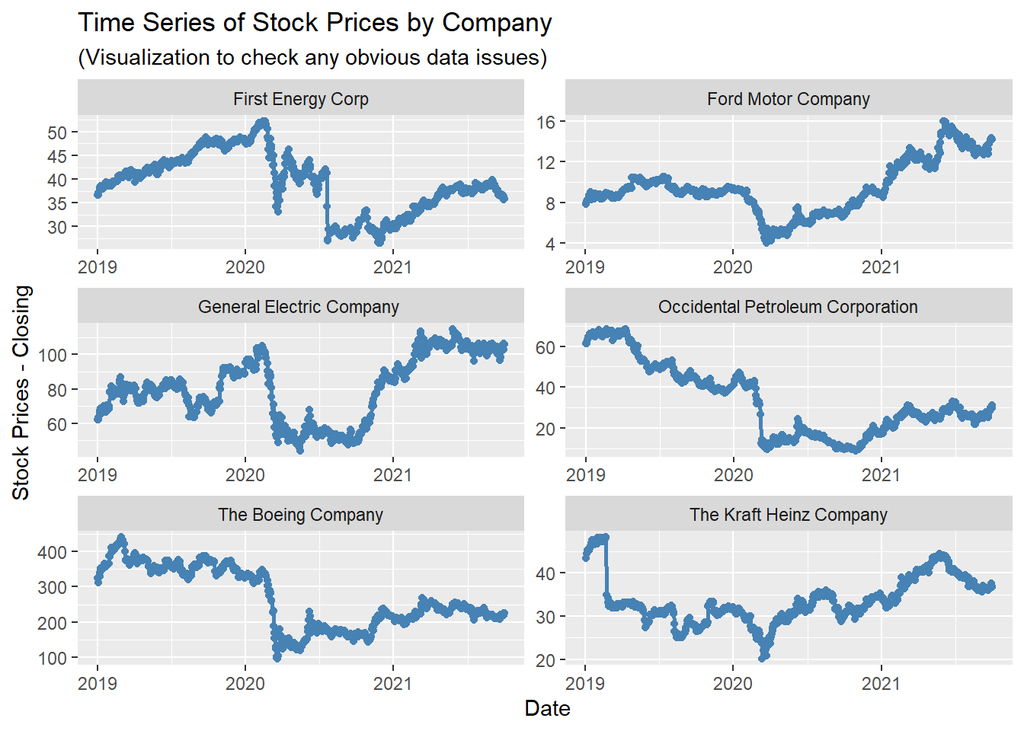

```r
ggplot(data = df_c_all, aes(period, Close)) +
  geom_line(color = "steelblue", size = 1) +
  geom_point(color = "steelblue") +
  labs(title = "Time Series of Stock Prices by Company",
       subtitle = "(Visualization to check any obvious data issues)",
       y = "Stock Prices - Closing ", x = " Date") +
  facet_wrap(~name,scales="free",ncol=2)
```

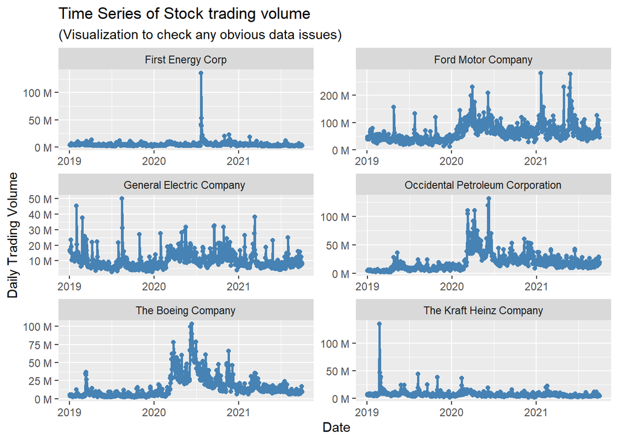

```r
ggplot(data = df_c_all, aes(period, Volume)) +
  geom_line(color = "steelblue", size = 1) +
  geom_point(color = "steelblue") +
  labs(title = "Time Series of Stock trading volume",
       subtitle = "(Visualization to check any obvious data issues)",
       y = "Daily Trading Volume", x = " Date") +
  facet_wrap(~name,scales="free",ncol=2) +
  scale_y_continuous(labels = label_number(suffix = " M", scale = 1e-6))
```

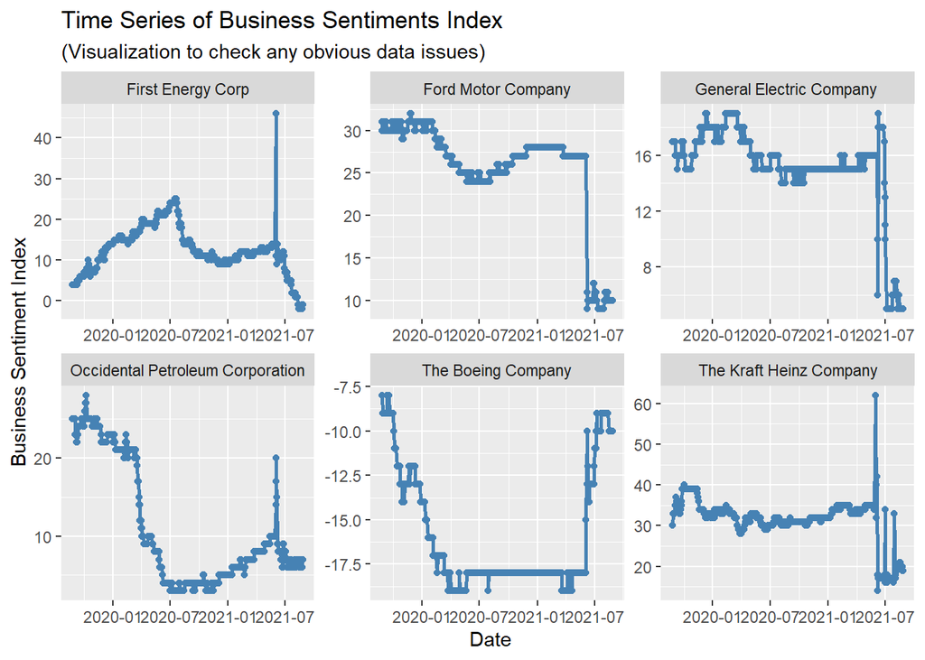

```r
ggplot(data = na.omit(df_bsi_all), aes(period,bsi_score)) +
  geom_line(color = "steelblue", size = 1) +
  geom_point(color = "steelblue") +
  labs(title = "Time Series of Business Sentiments Index",
       subtitle = "(Visualization to check any obvious data issues)",
       y = "Business Sentiment Index", x = " Date") +
  facet_wrap(~name,scales="free",ncol=3)
```